```python
!unzip data.zip
```

```python
import torch.nn as nn
import torch.nn.functional as F

class CNN(nn.Module):
    def __init__(self, input_channels=1, output_size=1, init_type='he', conv_activation_function= F.sigmoid, fc_activation_function= F.sigmoid):
        super(CNN, self).__init__()

        # --- Convolutional layers ---
        self.conv1 = nn.Conv2d(input_channels, 32, kernel_size=3, padding=1)
        self.conv2 = nn.Conv2d(32, 64, kernel_size=3, padding=1)
        self.conv3 = nn.Conv2d(64, 128, kernel_size=3, padding=1)

        # GAP sort un vecteur de taille 128
        self.gap = nn.AdaptiveAvgPool2d(1)

        # --- Fully connected layers ---
        self.fc1 = nn.Linear(128, 256)  # For 64x64 input
        self.fc2 = nn.Linear(256, output_size)

        # --- Weight initialization ---
        self.init_weights(init_type)

        # --- Activation functions ---
        self.conv_activation_function = conv_activation_function
        self.fc_activation_function = fc_activation_function

    def init_weights(self, init_type='he'):
        """Initialize weights according to chosen strategy"""
        for m in self.modules():
            if isinstance(m, (nn.Conv2d, nn.Linear)):
                if init_type == 'xavier':
                    nn.init.xavier_uniform_(m.weight)
                elif init_type == 'he':
                    nn.init.kaiming_uniform_(m.weight, nonlinearity='relu')
                elif init_type == 'uniform':
                    nn.init.uniform_(m.weight, -0.05, 0.05)
                elif init_type == 'normal':
                    nn.init.normal_(m.weight, 0.0, 0.02)
                else:
                    raise ValueError(f"Unknown init_type: {init_type}")
                if m.bias is not None:
                    nn.init.constant_(m.bias, 0)

    def forward(self, x, conv_activation_function=F.sigmoid, fc_activation_function=F.sigmoid):
        # --- Convolutional layers ---
        x = conv_activation_function(self.conv1(x))
        x = F.max_pool2d(x, 2)
        x = conv_activation_function(self.conv2(x))
        x = F.max_pool2d(x, 2)
        x = conv_activation_function(self.conv3(x))
        x = F.max_pool2d(x, 2)

        x = self.gap(x)              # (B, 128, 1, 1)

        # --- Flatten ---
        x = x.view(x.size(0), -1)

        # --- Fully connected layers ---
        x = fc_activation_function(self.fc1(x))
        x = self.fc2(x)  # linear output for regression

        return x
```

```python
import torch
from torch.utils.data import Dataset

class ArrowDataset(Dataset):
    def __init__(self, images, angles, transform=None):
        """
        images: numpy array of shape (N, H, W, 1)
        angles: numpy array of shape (N,)
        transform: optional torchvision transforms
        """
        self.images = images
        self.angles = angles
        self.transform = transform

    def __len__(self):
        return len(self.angles)

    def __getitem__(self, idx):
        image = self.images[idx]
        angle = self.angles[idx]

        # Convert to float32 tensor and move channel first
        image = torch.tensor(image, dtype=torch.float32).permute(2,0,1)  # (C,H,W)

        # Convert target to float32 tensor
        angle = torch.tensor(angle, dtype=torch.float32)

        if self.transform:
            image = self.transform(image)

        return image, angle
```

# CNNs for regression tasks

Convolutional Neural Networks (CNNs) are widely used for image classification tasks, but they can also be effectively applied to regression tasks. In regression tasks, the goal is to predict a continuous output variable based on input data.

On of the key elements in regression tasks using CNNs is the choice of the activation function in the convolutional (and fully connected) layers. While ReLU (Rectified Linear Unit) is a popular choice for classification tasks, it may not always be the best option for regression tasks.

```python
# Import necessary modules

import os, sys
import numpy as np
import pandas as pd
import matplotlib.pyplot as plt

import torch
import torch.nn as nn
from torch.utils.data import DataLoader

from sklearn.model_selection import train_test_split

# from cnns.cnn import CNN
# from ready_dataset import ArrowDataset
```

```python
# gpu check
device = torch.device("cuda" if torch.cuda.is_available() else "cpu")
print(f"Using device: {device}")
```

```
Using device: cuda
```

## Importing the data

We can now import the data to display several examples.

```python
data_df = pd.read_csv('./data/labels.csv')
images, angles = [], []
for idx, row in data_df.iterrows():
    img = plt.imread(os.path.join('./data/images', row['image_name']))
    images.append(img)
    angles.append(row['angle'])

    # restricting dataset size for faster training
    if idx >= 999:
        break

images = np.array(images)
angles = np.array(angles)
```

```python
# Prétraitement: retirer alpha (si présent), convertir en niveaux de gris, binariser, et remettre au format (N,H,W,1)
import numpy as np

# 1) Conversion en float32 et normalisation éventuelle vers [0,1]
if images.dtype == np.uint8:
    images = images.astype(np.float32) / 255.0
else:
    images = images.astype(np.float32)

print("Avant traitement:", images.shape, images.dtype, f"min={images.min():.3f}", f"max={images.max():.3f}")

# 2) Retirer le canal alpha si présent (RGBA -> RGB)
if images.shape[-1] == 4:
    images = images[..., :3]

# 3) Conversion en niveaux de gris
#    gray = 0.299 R + 0.587 G + 0.114 B
if images.shape[-1] == 3:
    images_gray = 0.299 * images[..., 0] + 0.587 * images[..., 1] + 0.114 * images[..., 2]
elif images.shape[-1] == 1:
    images_gray = images[..., 0]
else:
    raise ValueError(f"Nombre de canaux inattendu: {images.shape[-1]} (attendu 1 ou 3)")

# 4) Binarisation (seuil à 0.5)
images_bin = (images_gray >= 0.5).astype(np.float32)

# 5) Ajouter la dimension canal -> (N, H, W, 1), attendu par ArrowDataset
images = images_bin[..., None]

print("Après traitement:", images.shape, images.dtype, f"min={images.min():.1f}", f"max={images.max():.1f}")
# Sanity check sur la première image
u = np.unique(images[0])
print("Valeurs uniques (1ère image):", u[:10], "(nb=", len(u), ")")
```

```
Avant traitement: (1000, 64, 64, 4) float32 min=0.000 max=1.000
Après traitement: (1000, 64, 64, 1) float32 min=0.0 max=1.0
Valeurs uniques (1ère image): [0. 1.] (nb= 2 )
```

```python
print(f'Number of samples: {len(images)}')
print(f'Image shape: {images[0].shape}')
```

```
Number of samples: 1000
Image shape: (64, 64, 1)
```

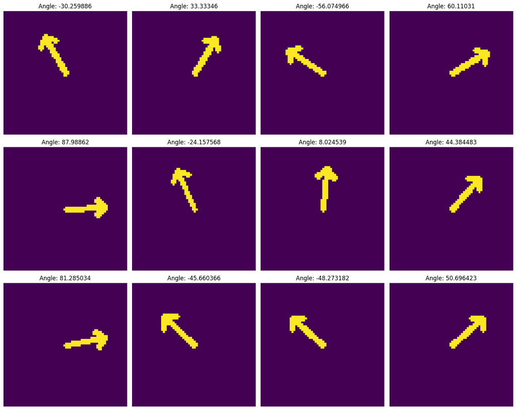

```python
# Display several examples (12)
fig, axes = plt.subplots(3, 4, figsize=(15, 12))
for i, ax in enumerate(axes.flat):
    ax.imshow(images[i])
    ax.set_title(f'Angle: {angles[i]}')
    ax.axis('off')
plt.tight_layout()
plt.show()
```

Note : Each angle is between -90 and 90 degrees. The angles are continuous values, measured in degrees and represent the orientation of the object in the image with respect to the y-axis (vertical axis). An angle of 0 degrees indicates that the object is perfectly vertical, while positive angles indicate a clockwise rotation and negative angles indicate a counterclockwise rotation.